# Sociabilidad, PNUD 2009

Juan Rivera

26 marzo 2021

## Introducción

El menú de la izquierda permite el rápido acceso a los conjuntos de preguntas.

Actualizaciones: - 25/03/2021: Se creo el archivo RMarkdown con la primera gráfica de la pregunta 15.

## Pregunta 15

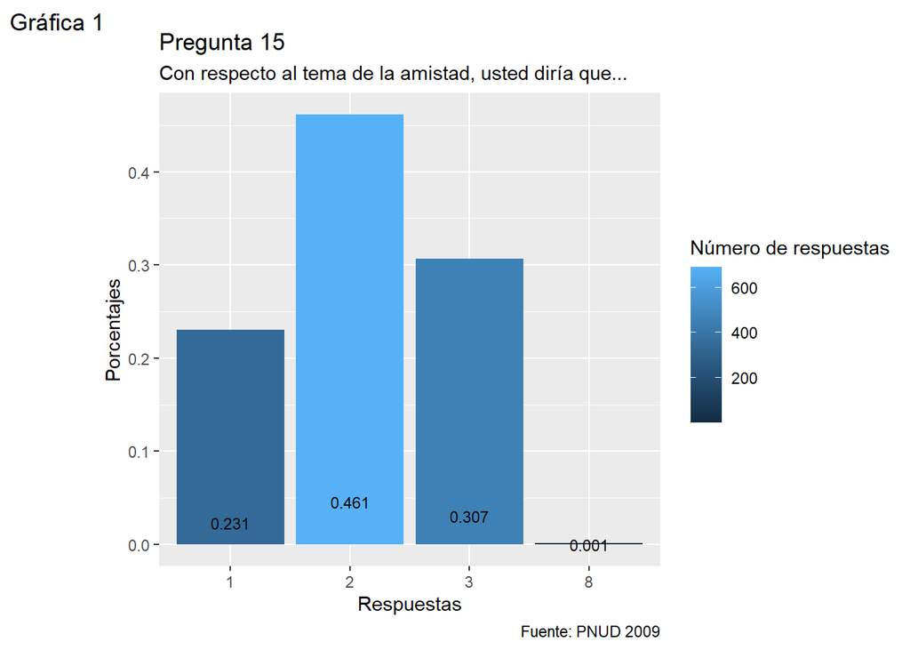

```r
ggplot(tbl15, aes(Respuesta, Porcentaje, fill = Conteo, label = round(Porcentaje, digits =3)))+
  geom_bar(stat = "identity")+
  geom_text(size = 3, position = position_stack(vjust = 0.1))+
  labs(
    title = "Pregunta 15",
    subtitle = "Con respecto al tema de la amistad, usted diría que...",
    y = "Porcentajes",
    x = "Respuestas",
    fill = "Número de respuestas",
    caption = "Fuente: PNUD 2009",
    tag = "Gráfica 1"
  )
```

## Pregunta 114

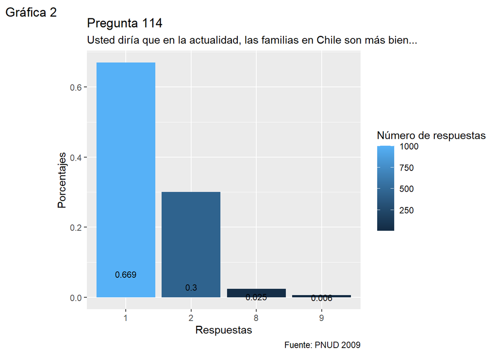

```r
ggplot(tbl114, aes(Respuesta, Porcentaje, fill = Conteo, label = round(Porcentaje, digits = 3)))+
  geom_bar(stat = "identity")+
  geom_text(size = 3, position = position_stack(vjust = 0.1))+
  labs(
    title = "Pregunta 114",
    subtitle = "Usted diría que en la actualidad, las familias en Chile son más bien...",
    y = "Porcentajes",
    x = "Respuestas",
    fill = "Número de respuestas",
    caption = "Fuente: PNUD 2009",
    tag = "Gráfica 2"
  )
```

## Pregunta 29B

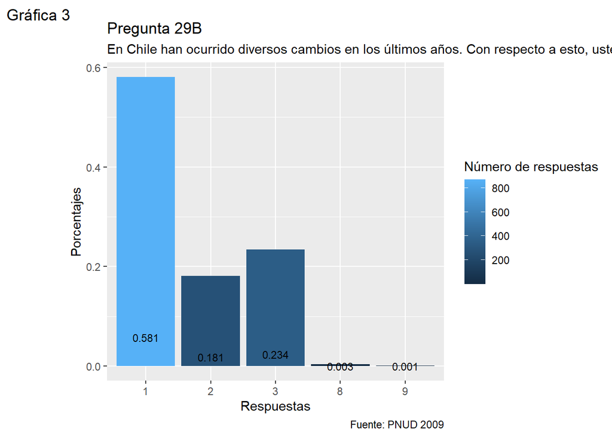

```r
ggplot(tbl29, aes(Respuesta, Porcentaje, fill = Conteo, label = round(Porcentaje, digits = 3)))+
  geom_bar(stat = "identity")+
  geom_text(size = 3, position = position_stack(vjust = 0.1))+
  labs(
    title = "Pregunta 29B",
    subtitle = "En Chile han ocurrido diversos cambios en los últimos años. Con respecto a esto, usted cree que hoy, ¿hay...",
    y = "Porcentajes",
    x = "Respuestas",
    fill = "Número de respuestas",
    caption = "Fuente: PNUD 2009",
    tag = "Gráfica 3"
  )
```

## Apéndice

```r
# Códigos opcionales
# Para remover valores 8 y 9:
# data %>%
# replace_with_na(replace = list(data.1 = c(8,9), data.2 = c(8,9),
  #                             data.3 = c(8,9), data.4 = c(8, 9),
   #                            data.5 = c(8,9))) -> data
#Después graficar de manera normal, modificando los valores del mutate que correspondan.
```

## Preguntas y respuestas completas

- P15: “Con respecto al tema de la amistad, usted diría que…”
  - Tiene muchos amigos: 1
  - Tiene pocos amigos: 2
  - No tiene amigos, solo conocidos: 3
  - NS: 8
  - NR: 9
- P114: “Usted diría que en la actualidad, las familias en Chile son más bien…”
  - Un lugar en el cual encontrar descanso y apoyo: 1
  - Una fuente de tensiones y problemas: 2
  - NS: 8
  - NR: 9
- P29B: “En Chile han ocurrido diversos cambios en los últimos años. Con respecto a esto, usted cree que hoy, ¿hay mayores, menores, o las mismas oportunidades en el país para…? B. EXPRESAR LO QUE SE PIENSA”
  - Hay mayores oportunidades: 1
  - Hay menores oportunidades: 2
  - Hay las mismas oportunidades: 3
  - NS: 8
  - NR: 9
- P62_1 y P62_2: “De la siguiente lista, ¿me podría indicar cuáles son las dos peores maneras de hacer las cosas de los chilenos?”
  - Nos cuesta decirnos las cosas a la cara: 1
  - Nos pasamos mucho a llevar: 2
  - Hacemos las cosas al lote: 3
  - Hacemos siempre las cosas a última hora: 4
  - Llegamos siempre atrasados: 5
  - Aparentamos lo que no somos: 6
  - Tomamos decisiones sin consultarle a los demás: 7
  - NS: 8
  - NR: 9
  - Ninguna: 10